# Wine Data Analysis

### Overview

The wine dataset includes many characteristics about each type of wine. Each type of wine will be given a quality from 1 to 8. In this analysis, we will classify wine that has quality greater than 6 as high quality wine, otherwise, low quality wine. We will give high quality wine 1, low quality wine 0. Next, we will split the data into training and test set. We will use training set to build models, and utilize test set to predict whether a wine is high quality or not. In addition, we will be using 0.5 as our threshhold.

### Import Dataset

Import the data we need.

```r
rm(list=ls())
setwd("D:/2021 fall/machine learning/module8/coursework")
dat <- read.table("winequality-red.csv", sep=";", header=TRUE)
library(psych)
```

### Preparing Data

In this section, our wine quality has 3-8, 6 kinds of different grades. We define wine having quaility bigger than 6 is high quality wine. We give high quality wine 1, the rest 0.

```r
table(dat$quality)
```

```
##
##   3   4   5   6   7   8
##  10  53 681 638 199  18
```

```r
dat$quality <- I(dat$quality > 6) * 1
```

We split 70% of the data into training set, and the rest as test set.

```r
set.seed(42)
trn <- runif(nrow(dat)) < .7
train <- dat[trn==TRUE,]
test <- dat[trn==FALSE,]
```

### Logistic Regression

We fit training data to a logistic regression, and use test set to make predictions. We then calculate TPR,TNR for training set and test set.Since we run this before, the result was hidden.

```r
glm <- glm(quality ~ ., family="binomial", data=train)
yhat_glm <- predict(glm, type="response")
test_yhat.glm <- predict(glm, test, type="response")
```

### True Positive Rate (Training Set)

```r
TPR <- function(y,yhat)  { sum(y==1 & yhat==1) / sum(y==1) }
TPR(train$quality, (yhat_glm >0.5))
```

```
## [1] 0.3618421
```

### True Negative Rate (Training Set)

```r
TNR <- function(y,yhat)  { sum(y==0 & yhat==0) / sum(y==0) }
TNR(train$quality, (yhat_glm >0.5))
```

```
## [1] 0.9684959
```

### Confusion Matrix

Plotting confusion matrix for our prediction based on test set.

```r
table(test$quality, (test_yhat.glm  > 0.5))
```

```
##
##     FALSE TRUE
##   0   384   14
##   1    46   19
```

### True Positive Rate (Test Set)

```r
TPR(test$quality, (test_yhat.glm  > 0.5))
```

```
## [1] 0.2923077
```

### True Negative Rate (Test Set)

```r
TNR(test$quality, (test_yhat.glm  > 0.5))
```

```
## [1] 0.9648241
```

### Roc Curve

```r
library(pROC)
glm.roc <- roc(test$quality, test_yhat.glm, direction="<")
glm.roc
```

```
##
## Call:
## roc.default(response = test$quality, predictor = test_yhat.glm,     direction = "<")
##
## Data: test_yhat.glm in 398 controls (test$quality 0) < 65 cases (test$quality 1).
## Area under the curve: 0.8777
```

```r
plot(glm.roc, lwd=3)
```

[output not shown]

### LDA

```r
library(MASS)
library(pROC)
lda <- lda(quality ~ ., data=train)
yhat_lda <- predict(lda)$posterior[,2]
test_yhat.lda <- predict(lda, test)$posterior[,2]
```

### Confusion Matrix

Plotting confusion matrix for our prediction based on test set.

```r
table(test$quality, (test_yhat.lda > 0.5))
```

```
##
##     FALSE TRUE
##   0   375   23
##   1    39   26
```

### Roc Curve

```r
lda.roc <- roc(test$quality, test_yhat.lda, direction="<")
lda.roc
```

```
##
## Call:
## roc.default(response = test$quality, predictor = test_yhat.lda,     direction = "<")
##
## Data: test_yhat.lda in 398 controls (test$quality 0) < 65 cases (test$quality 1).
## Area under the curve: 0.8814
```

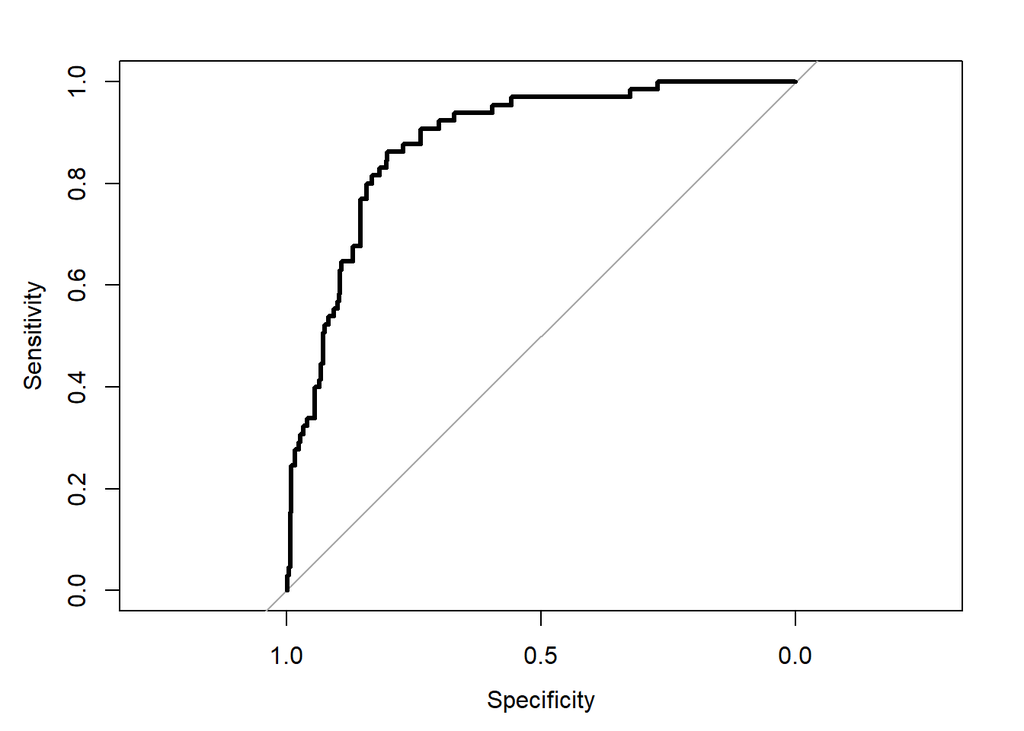

```r
plot(lda.roc, lwd=3)
```

### QDA

```r
qda <- qda(quality ~ ., data=train)
yhat_qda <- predict(qda)$posterior[,2]
test_yhat.qda <- predict(qda, test)$posterior[,2]
```

### Confusion Matrix

Plotting confusion matrix for our prediction based on test set.

```r
table(test$quality, (test_yhat.qda > 0.5))
```

```
##
##     FALSE TRUE
##   0   351   47
##   1    29   36
```

### Roc Curve

```r
qda.roc <- roc(test$quality, test_yhat.qda, direction="<")
qda.roc
```

```
##
## Call:
## roc.default(response = test$quality, predictor = test_yhat.qda,     direction = "<")
##
## Data: test_yhat.qda in 398 controls (test$quality 0) < 65 cases (test$quality 1).
## Area under the curve: 0.8458
```

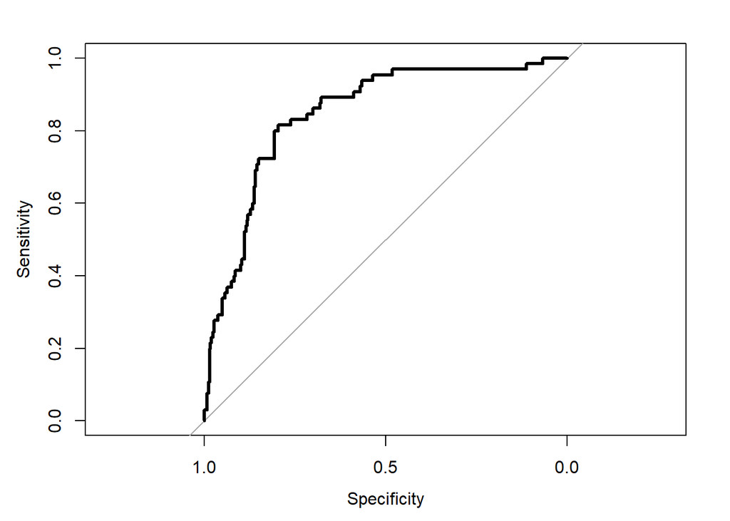

```r
plot(qda.roc, lwd=3)
```

### Classification Tree

We use rpart to generate classification tree with training data.

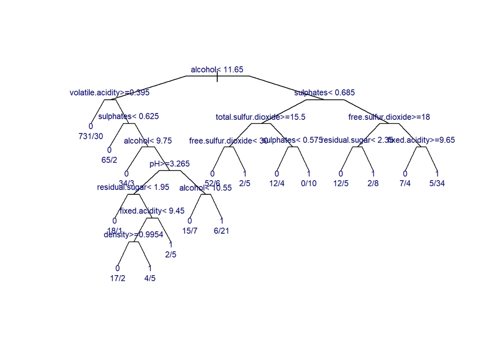

```r
library(rpart)

form1 <- formula(quality ~ fixed.acidity + volatile.acidity + citric.acid
                 + residual.sugar + chlorides + free.sulfur.dioxide
                 + total.sulfur.dioxide + density + pH + sulphates + alcohol)

t1 <- rpart(form1 ,data = train,cp=.001, method="class")
plot(t1,uniform=T,compress=T,margin=.05,branch=0.3)
text(t1, cex=.7, col="navy",use.n=TRUE)
```

### Confusion Matrix

We use the model above to generate predictions with test set. We determine the confsion matrix with a 50% threshold.

```r
yhat.t1 <- predict(t1, test, type="prob")[,2]

table(test$quality,yhat.t1>0.5)
```

```
##
##     FALSE TRUE
##   0   375   23
##   1    34   31
```

```r
TPR(test$quality, (yhat.t1>0.5))
```

```
## [1] 0.4769231
```

```r
TNR(test$quality, (yhat.t1>0.5))
```

```
## [1] 0.9422111
```

### Plot a ROC curve

```r
library(pROC)
t1.roc <- roc(test$quality, yhat.t1, direction="<")
t1.roc
```

```
##
## Call:
## roc.default(response = test$quality, predictor = yhat.t1, direction = "<")
##
## Data: yhat.t1 in 398 controls (test$quality 0) < 65 cases (test$quality 1).
## Area under the curve: 0.7982
```

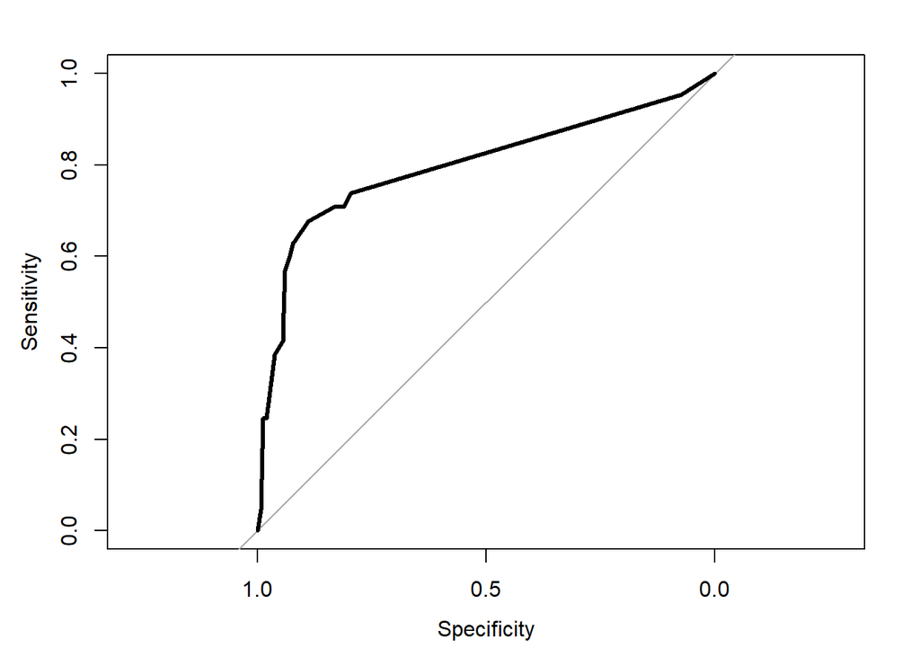

```r
plot(t1.roc, lwd=3)
```

### Plotting ROC Curve of Classification Tree, LDA, QDA, Logistic Regression

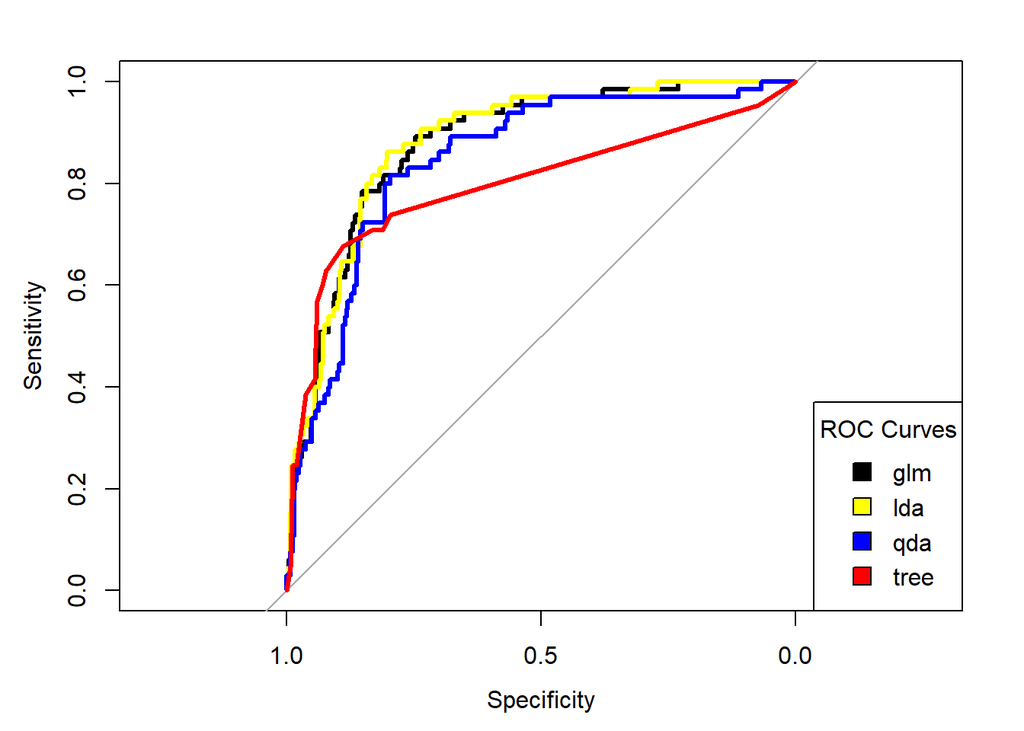

```r
par(mfrow=c(1,1))
plot(glm.roc, lwd=3)
lines(lda.roc, lwd=3, col = "yellow")
lines(qda.roc, lwd=3, col = "blue")
lines(t1.roc, lwd=3, col = "red")
legend("bottomright",title="ROC Curves",c("glm","lda","qda","tree"), fill=c("black","yellow","blue","red"))
```